# Part I - Ford GoBike System Data

## Introduction

The dataset contains details regarding rides taken within a bike-sharing network spanning the expansive San Francisco Bay area. It comprises 183,412 entries across 16 distinct categories. Among these attributes are the duration of each trip, its commencement and conclusion timestamps including dates, the names of originating and destination stations, corresponding coordinates for both starting and ending points, customer classification, whether the bike was shared for the entire journey, and the method used for rental access.

## Preliminary Wrangling

```python
# import all packages and set plots to be embedded inline
import numpy as np
from sklearn.preprocessing import LabelEncoder
import pandas as pd
import matplotlib.pyplot as plt
from mpl_toolkits.mplot3d import Axes3D
import seaborn as sns
%matplotlib inline
```

## Data Gathering

```python
df = pd.read_csv('data/201902-fordgobike-tripdata.csv')
df
```

|  | duration_sec | start_time | end_time | start_station_id | start_station_name | start_station_latitude | start_station_longitude | end_station_id | end_station_name | end_station_latitude | end_station_longitude | bike_id | user_type | member_birth_year | member_gender | bike_share_for_all_trip |
| --- | --- | --- | --- | --- | --- | --- | --- | --- | --- | --- | --- | --- | --- | --- | --- | --- |
| 0 | 52185 | 2019-02-28 17:32:10.1450 | 2019-03-01 08:01:55.9750 | 21.0 | Montgomery St BART Station (Market St at 2nd St) | 37.789625 | -122.400811 | 13.0 | Commercial St at Montgomery St | 37.794231 | -122.402923 | 4902 | Customer | 1984.0 | Male | No |
| 1 | 42521 | 2019-02-28 18:53:21.7890 | 2019-03-01 06:42:03.0560 | 23.0 | The Embarcadero at Steuart St | 37.791464 | -122.391034 | 81.0 | Berry St at 4th St | 37.775880 | -122.393170 | 2535 | Customer | NaN | NaN | No |
| 2 | 61854 | 2019-02-28 12:13:13.2180 | 2019-03-01 05:24:08.1460 | 86.0 | Market St at Dolores St | 37.769305 | -122.426826 | 3.0 | Powell St BART Station (Market St at 4th St) | 37.786375 | -122.404904 | 5905 | Customer | 1972.0 | Male | No |
| 3 | 36490 | 2019-02-28 17:54:26.0100 | 2019-03-01 04:02:36.8420 | 375.0 | Grove St at Masonic Ave | 37.774836 | -122.446546 | 70.0 | Central Ave at Fell St | 37.773311 | -122.444293 | 6638 | Subscriber | 1989.0 | Other | No |
| 4 | 1585 | 2019-02-28 23:54:18.5490 | 2019-03-01 00:20:44.0740 | 7.0 | Frank H Ogawa Plaza | 37.804562 | -122.271738 | 222.0 | 10th Ave at E 15th St | 37.792714 | -122.248780 | 4898 | Subscriber | 1974.0 | Male | Yes |
| ... | ... | ... | ... | ... | ... | ... | ... | ... | ... | ... | ... | ... | ... | ... | ... | ... |
| 183407 | 480 | 2019-02-01 00:04:49.7240 | 2019-02-01 00:12:50.0340 | 27.0 | Beale St at Harrison St | 37.788059 | -122.391865 | 324.0 | Union Square (Powell St at Post St) | 37.788300 | -122.408531 | 4832 | Subscriber | 1996.0 | Male | No |
| 183408 | 313 | 2019-02-01 00:05:34.7440 | 2019-02-01 00:10:48.5020 | 21.0 | Montgomery St BART Station (Market St at 2nd St) | 37.789625 | -122.400811 | 66.0 | 3rd St at Townsend St | 37.778742 | -122.392741 | 4960 | Subscriber | 1984.0 | Male | No |
| 183409 | 141 | 2019-02-01 00:06:05.5490 | 2019-02-01 00:08:27.2200 | 278.0 | The Alameda at Bush St | 37.331932 | -121.904888 | 277.0 | Morrison Ave at Julian St | 37.333658 | -121.908586 | 3824 | Subscriber | 1990.0 | Male | Yes |
| 183410 | 139 | 2019-02-01 00:05:34.3600 | 2019-02-01 00:07:54.2870 | 220.0 | San Pablo Ave at MLK Jr Way | 37.811351 | -122.273422 | 216.0 | San Pablo Ave at 27th St | 37.817827 | -122.275698 | 5095 | Subscriber | 1988.0 | Male | No |
| 183411 | 271 | 2019-02-01 00:00:20.6360 | 2019-02-01 00:04:52.0580 | 24.0 | Spear St at Folsom St | 37.789677 | -122.390428 | 37.0 | 2nd St at Folsom St | 37.785000 | -122.395936 | 1057 | Subscriber | 1989.0 | Male | No |

183412 rows × 16 columns

## Data Accessing

```python
df.sample()
```

|  | duration_sec | start_time | end_time | start_station_id | start_station_name | start_station_latitude | start_station_longitude | end_station_id | end_station_name | end_station_latitude | end_station_longitude | bike_id | user_type | member_birth_year | member_gender | bike_share_for_all_trip |
| --- | --- | --- | --- | --- | --- | --- | --- | --- | --- | --- | --- | --- | --- | --- | --- | --- |
| 151984 | 1097 | 2019-02-06 16:29:31.3880 | 2019-02-06 16:47:49.1060 | 116.0 | Mississippi St at 17th St | 37.764802 | -122.394771 | 15.0 | San Francisco Ferry Building (Harry Bridges Pl... | 37.795392 | -122.394203 | 5329 | Subscriber | 1960.0 | Female | No |

```python
df.shape
```

```
(183412, 16)
```

```python
df.describe()
```

|  | duration_sec | start_station_id | start_station_latitude | start_station_longitude | end_station_id | end_station_latitude | end_station_longitude | bike_id | member_birth_year |
| --- | --- | --- | --- | --- | --- | --- | --- | --- | --- |
| count | 183412.000000 | 183215.000000 | 183412.000000 | 183412.000000 | 183215.000000 | 183412.000000 | 183412.000000 | 183412.000000 | 175147.000000 |
| mean | 726.078435 | 138.590427 | 37.771223 | -122.352664 | 136.249123 | 37.771427 | -122.352250 | 4472.906375 | 1984.806437 |
| std | 1794.389780 | 111.778864 | 0.099581 | 0.117097 | 111.515131 | 0.099490 | 0.116673 | 1664.383394 | 10.116689 |
| min | 61.000000 | 3.000000 | 37.317298 | -122.453704 | 3.000000 | 37.317298 | -122.453704 | 11.000000 | 1878.000000 |
| 25% | 325.000000 | 47.000000 | 37.770083 | -122.412408 | 44.000000 | 37.770407 | -122.411726 | 3777.000000 | 1980.000000 |
| 50% | 514.000000 | 104.000000 | 37.780760 | -122.398285 | 100.000000 | 37.781010 | -122.398279 | 4958.000000 | 1987.000000 |
| 75% | 796.000000 | 239.000000 | 37.797280 | -122.286533 | 235.000000 | 37.797320 | -122.288045 | 5502.000000 | 1992.000000 |
| max | 85444.000000 | 398.000000 | 37.880222 | -121.874119 | 398.000000 | 37.880222 | -121.874119 | 6645.000000 | 2001.000000 |

```python
df.info()
```

```
<class 'pandas.core.frame.DataFrame'>
RangeIndex: 183412 entries, 0 to 183411
Data columns (total 16 columns):
 #   Column                   Non-Null Count   Dtype
---  ------                   --------------   -----
 0   duration_sec             183412 non-null  int64
 1   start_time               183412 non-null  object
 2   end_time                 183412 non-null  object
 3   start_station_id         183215 non-null  float64
 4   start_station_name       183215 non-null  object
 5   start_station_latitude   183412 non-null  float64
 6   start_station_longitude  183412 non-null  float64
 7   end_station_id           183215 non-null  float64
 8   end_station_name         183215 non-null  object
 9   end_station_latitude     183412 non-null  float64
 10  end_station_longitude    183412 non-null  float64
 11  bike_id                  183412 non-null  int64
 12  user_type                183412 non-null  object
 13  member_birth_year        175147 non-null  float64
 14  member_gender            175147 non-null  object
 15  bike_share_for_all_trip  183412 non-null  object
dtypes: float64(7), int64(2), object(7)
memory usage: 22.4+ MB
```

## Data Cleaning

```python
df.dropna(inplace=True)
df.isnull().sum()
```

```
duration_sec               0
start_time                 0
end_time                   0
start_station_id           0
start_station_name         0
start_station_latitude     0
start_station_longitude    0
end_station_id             0
end_station_name           0
end_station_latitude       0
end_station_longitude      0
bike_id                    0
user_type                  0
member_birth_year          0
member_gender              0
bike_share_for_all_trip    0
dtype: int64
```

```python
df.drop_duplicates(inplace=True)
df.duplicated().sum()
```

```
0
```

```python
df.shape
```

```
(174952, 16)
```

### What is the structure of your dataset?

The raw dataset has dimensions of (183412, 16), and after cleaning, it shrinks to (174952, 16).

### What is/are the main feature(s) of interest in your dataset?

The main feature within this dataset are the `age`, `user type`, and `gender` of the user, as well as the `duration` of each trip.

### What features in the dataset do you think will help support your investigation into your feature(s) of interest?

Features that can further support my interest include `bike_id`, `member_birth_year`, `member_gender`, `duration_sec`, `user_type`, `start_time`, and `end_time`.

## Univariate Exploration

```python
def plot_bar_chart(feature):
    # Bar chart
    feature_counts = df[feature].value_counts()
    plt.figure(figsize=(8, 6))
    feature_counts.plot(kind='bar', color='lightcoral')
    plt.title(f'Count of {feature}')
    plt.xlabel(feature)
    plt.ylabel('Count')
    plt.xticks(rotation=45)
    plt.tight_layout()
    plt.show()
```

```python
def plot_pie_chart(feature):
    # Pie chart
    feature_counts = df[feature].value_counts(normalize=True) * 100
    plt.figure(figsize=(8, 6))
    plt.pie(feature_counts, labels=feature_counts.index, autopct='%1.1f%%', startangle=140)
    plt.title(f'Percentage of {feature}')
    plt.axis('equal')
    plt.tight_layout()
    plt.show()
```

### What is the distribution of bike share for all trip?

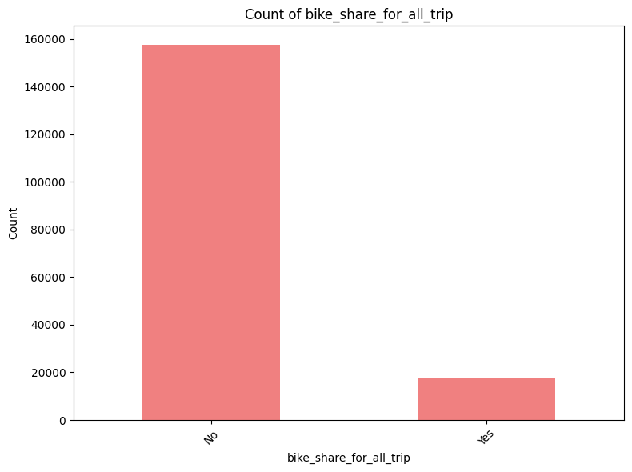

```python
plot_bar_chart('bike_share_for_all_trip')
```

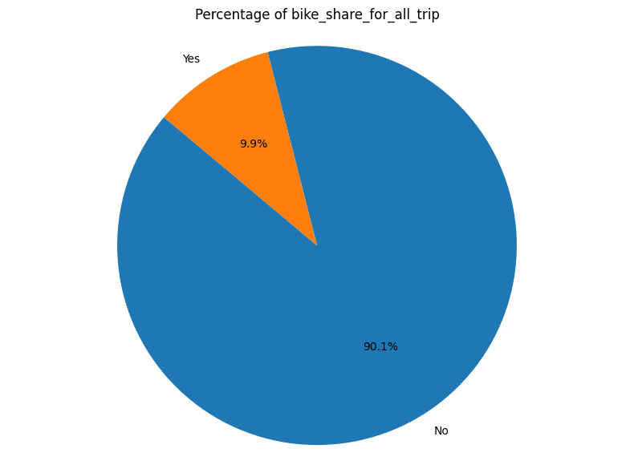

```python
plot_pie_chart('bike_share_for_all_trip')
```

Looking at the chart above, we can easily observe that the 'No' group has a significantly higher proportion, evidenced by 90% No and 10% Yes. This explains that the allocation of bike shares for all trips is not uniform; it could stem from various factors such as age, gender, trip purpose, trip duration, and stations.

### What is the gender distribution of participants?

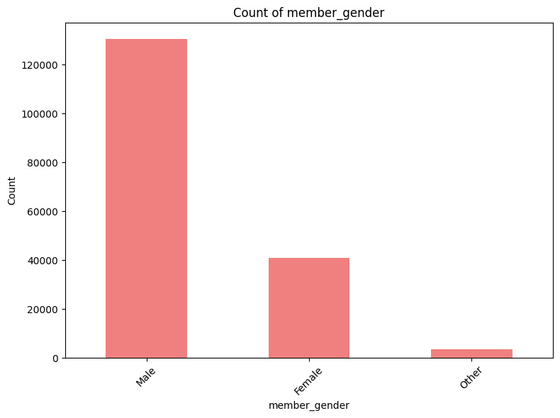

```python
plot_bar_chart('member_gender')
```

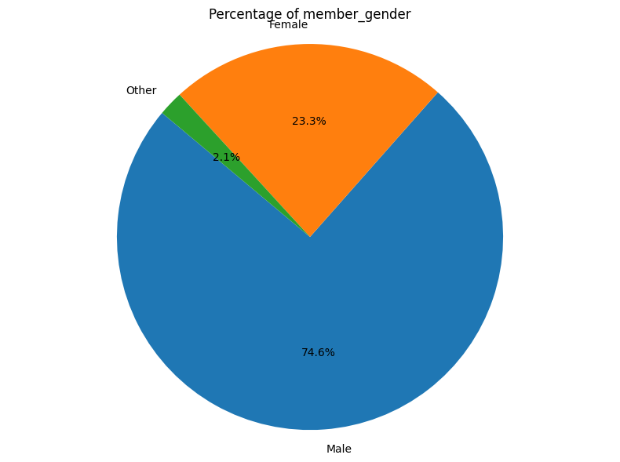

```python
plot_pie_chart('member_gender')
```

A clear fact is that the number of men participating in cycling always dominates compared to other genders, and cycling is no exception. According to the analysis, we have a male index of 74.6%, a female index of 23.3%, and other genders at 2.1%.

### What is the distribution of user types?

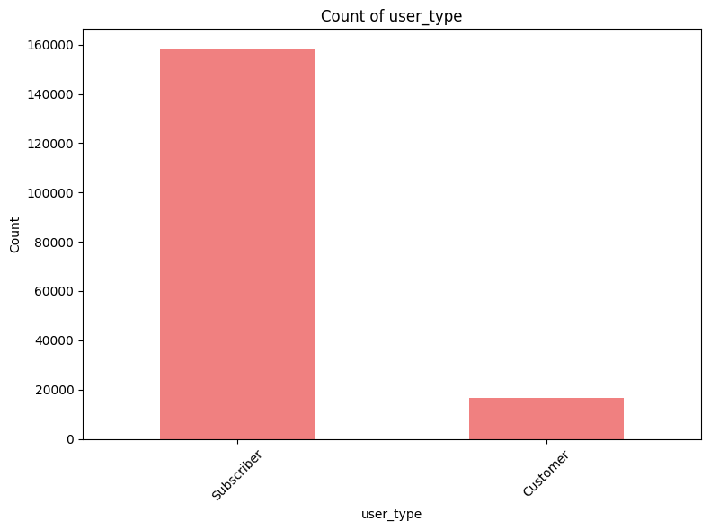

```python
plot_bar_chart('user_type')
```

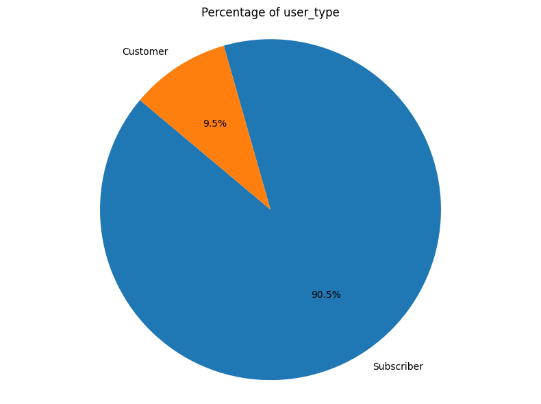

```python
plot_pie_chart('user_type')
```

Looking at the chart again, it's no surprise that registered users once again account for a significant portion compared to casual visitors. It's a simple principle; those who are committed always make up the majority.

```python
def plot_histogram(feature):
    # Histogram
    plt.figure(figsize=(10, 6))
    plt.hist(df[feature], bins=30, color='lightcoral', edgecolor='black')
    plt.title(f'Distribution of {feature.capitalize()}')
    plt.xlabel(feature.capitalize())
    plt.ylabel('Frequency')
    plt.grid(True)
    if feature == 'duration_sec':
        plt.xlim(0,8000)
    plt.tight_layout()
    plt.show()
```

### The distribution of age among participants is how?

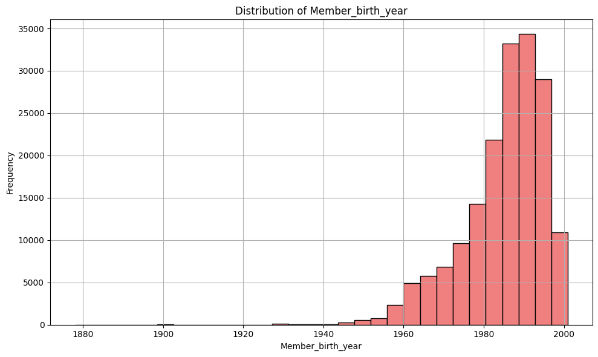

```python
plot_histogram('member_birth_year')
```

Looking at the chart, we can easily see that the age group from 20 to 40 years old predominates. This explains that younger individuals are more involved.

### How is the distribution of trip duration?

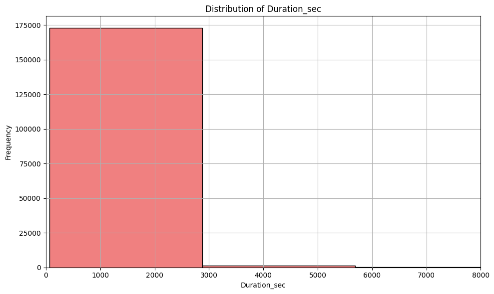

```python
plot_histogram('duration_sec')
```

### Discuss the distribution(s) of your variable(s) of interest. Were there any unusual points? Did you need to perform any transformations?

The data exhibits uneven distributions, with focal values often dominating the frequency within the dataset. For instance, the distribution of `duration_sec` was highly concentrated, so I used the method of limiting the x-axis of the histogram to focus on displaying the data more effectively.

### Of the features you investigated, were there any unusual distributions? Did you perform any operations on the data to tidy, adjust, or change the form of the data? If so, why did you do this?

the data still contained invalid entries across variables. I employed methods to normalize the data, clean it, and remove duplicate elements. Regarding the distribution of the data, it predominantly leaned towards a particular type, resulting in the frequency of one value predominating the overall dataset. This uneven distribution of values can be observed by sequentially examining the analyzed charts:

## Bivariate Exploration

```python
def plot_scatter(variable1, variable2):
    # Create a color gradient from light red to dark red
    cmap = plt.cm.get_cmap('Reds')
    colors = np.linspace(0, 1, len(df))

    # Scatter plot with color gradient
    plt.figure(figsize=(10, 6))
    plt.scatter(df[variable1], df[variable2], c=colors, cmap=cmap, alpha=0.5)
    plt.colorbar(label='Color Gradient')  # Add color bar legend
    plt.title(f'Scatter Plot of {variable2.capitalize()} vs. {variable1.capitalize()}')
    plt.xlabel(variable1.capitalize())
    plt.ylabel(f'{variable2.capitalize()}')
    plt.grid(True)
    plt.tight_layout()
    plt.show()
```

### What is the correlation between member birth year and trip duration in seconds?

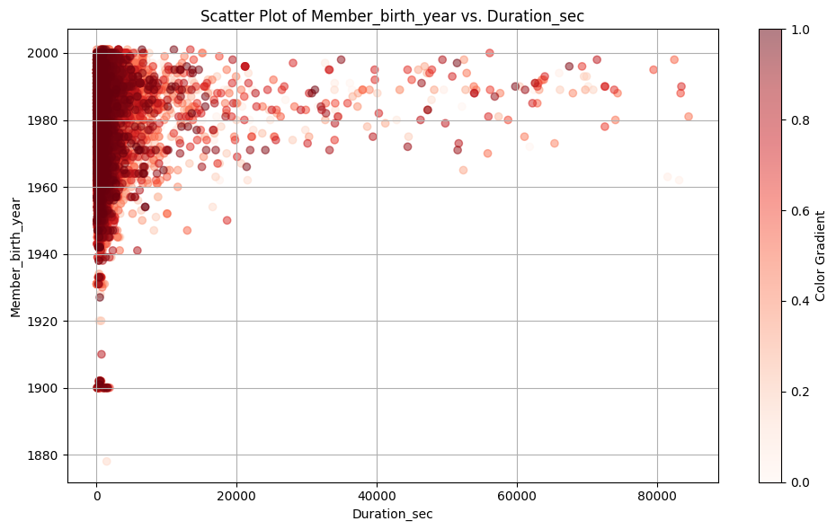

```python
plot_scatter('duration_sec','member_birth_year')
```

Looking at the chart, we can easily observe that younger individuals tend to have longer trip durations. This may be due to the fact that younger people often have better endurance, and younger generations increasingly favor this activity.

```python
def plot_box(variable1, variable2):
    plt.figure(figsize=(10, 6))
    df.groupby(variable2)[variable1].count().plot(kind='bar', color='skyblue')
    plt.title('Number of {} by {}'.format(variable1.capitalize(), variable2.capitalize()))
    plt.xlabel(variable2.capitalize())
    plt.ylabel('Count')
    plt.grid(axis='y')
    plt.tight_layout()
    plt.show()
```

```python
def plot_boxplot(variable1, variable2):
    plt.figure(figsize=(10, 6))
    sns.boxplot(x=variable2, y=variable1, data=df, palette='Reds')
    plt.xlabel(variable2, fontsize=12, color='black')
    plt.ylabel(variable1, fontsize=12, color='black')
    plt.title('Box plot of ' + variable1 + ' by ' + variable2, fontsize=14, color='black')
    plt.xticks(rotation=45, fontsize=10, color='black')
    plt.yticks(fontsize=10, color='black')
    plt.show()
```

### How is the distribution of user types by age?

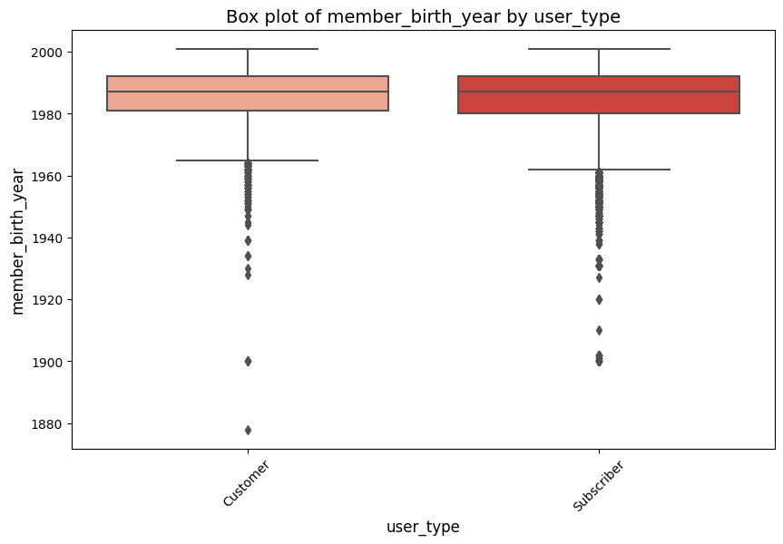

```python
plot_boxplot('member_birth_year','user_type')
```

We can clearly see that the median indices of both user types, customer and subscriber, are concentrated around the range from 1980 to 2000. This explains that individuals in this age group constitute the majority compared to the total.

### How is the distribution of member gender by age?

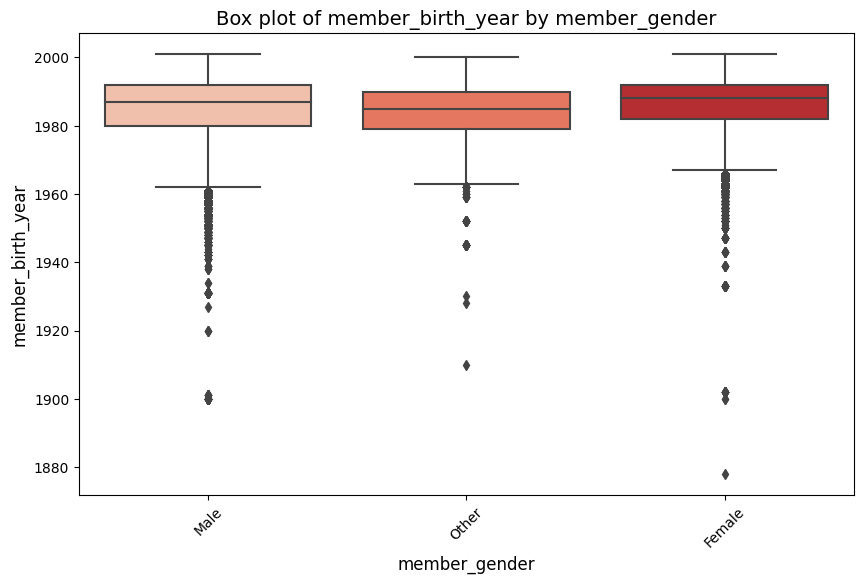

```python
plot_boxplot('member_birth_year','member_gender')
```

Similarly to user types, we can clearly see that the median indices of all 3 gender types, male, female, and others, are concentrated around the range from 1980 to 2000. This explains that individuals in this age group also constitute the majority compared to the total.

### What is the correlation between member gender and user type?

```python
def plot_clustered_bar_chart(variable1, variable2):
    data = df[[variable1, variable2]]

    group_counts = data.groupby([variable1, variable2]).size().unstack()

    group_counts.plot(kind='bar', stacked=False, color=['lightcoral', 'darkred'])

    plt.xlabel(variable1, fontweight='bold')
    plt.ylabel('Count', fontweight='bold')
    plt.title('Clustered Bar Chart of ' + variable1 + ' and ' + variable2, fontsize=14)
    plt.xticks(rotation=0)

    plt.legend(title=variable2)
    plt.show()
```

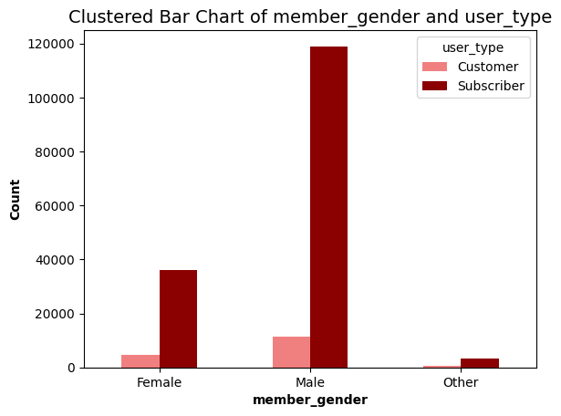

```python
plot_clustered_bar_chart('member_gender','user_type')
```

Looking at the chart, we can easily observe that gender correlates with user type. Whichever gender dominates, the corresponding user type also dominates.

### Talk about some of the relationships you observed in this part of the investigation. How did the feature(s) of interest vary with other features in the dataset?

Through the charts and analysis, we have clearly and reasonably observed a truth that aligns with the human biological activity. We can easily see that the majority of registered users dominate the list, rather than casual visitors, and most of them are males. Additionally, age also plays a significant role. The younger the age, the longer the duration of trips and the more frequent the appearances. This is evidence that younger people greatly enjoy cycling activities.

Features that are of interest clearly demonstrate the characteristics of the dataset more than those that are not of interest.

## Multivariate Exploration

```python
def plot_facetgrid(variable1, variable2, variable3):
    sns.set(style="ticks")
    g = sns.FacetGrid(df, col=variable1, hue=variable1, palette="Reds", height=4, aspect=1.5)
    g.map(plt.scatter, variable2, variable3, alpha=.7)
    g.add_legend()
    plt.show()
```

### What is the significance of the relationship between member gender, member birth year, and trip duration in seconds?

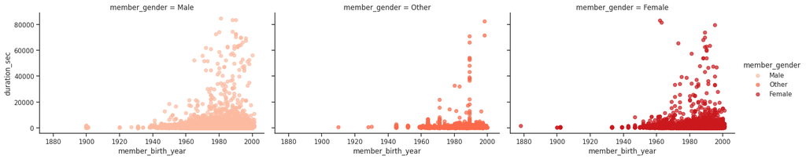

```python
plot_facetgrid('member_gender','member_birth_year', 'duration_sec')
```

Looking at the chart, we can easily observe the distribution of trip duration and the age of participants corresponding to each gender. Here, we see that participants aged 20 to 40 years old constitute the largest proportion for all three genders. Additionally, trip duration is highest among males, followed by females and then other genders. This is entirely consistent with the societal norms of human activity.

### What is the correlation between start time, end time, and trip duration in seconds?

```python
def preprocess_time(df):
    """
    Preprocess 'start_time' and 'end_time' columns to obtain numerical values.

    Parameters:
    - df: DataFrame containing the data.

    Returns:
    - df: DataFrame with preprocessed time columns.
    """
    df['start_time_numeric'] = pd.to_datetime(df['start_time']).astype(int)
    df['end_time_numeric'] = pd.to_datetime(df['end_time']).astype(int)
    return df

def plot_3d_bar_time(df):
    """
    Create a 3D bar plot to show the correlation between 'start_time', 'end_time', and 'duration_sec'.

    Parameters:
    - df: DataFrame containing the data.
    """
    fig = plt.figure(figsize=(10, 8))
    ax = fig.add_subplot(111, projection='3d')

    # Extracting data
    x_values = df['start_time_numeric']
    y_values = df['end_time_numeric']
    z_values = df['duration_sec']

    # Plot bars for each data point
    ax.bar3d(x_values, y_values, 0, 1, 1, z_values, color='red', edgecolor='red')

    # Set labels and title
    ax.set_xlabel('Start Time')
    ax.set_ylabel('End Time')
    ax.set_zlabel('Duration (sec)')
    ax.set_title('Correlation Between Start Time, End Time, and Duration')

    plt.show()
```

```python
# Preprocess time columns
df = preprocess_time(df)
```

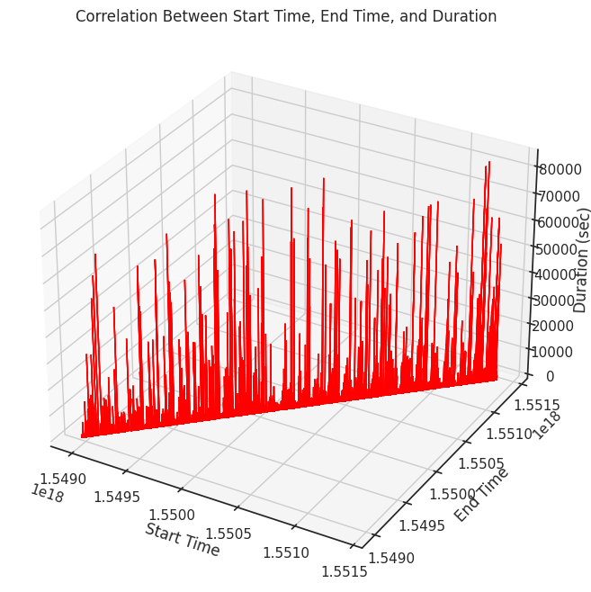

```python
# Plot 3D bar plot
plot_3d_bar_time(df)
```

Finally, I utilized a 3D chart combined with multiple variables to best illustrate the correlation between start time, end time, and trip duration in seconds. In this chart, we can easily observe that the distribution of trip duration is fairly even across the start and end time frames.

### Talk about some of the relationships you observed in this part of the investigation. Were there features that strengthened each other in terms of looking at your feature(s) of interest?

The durations of trips are evenly and reasonably distributed within the time frame from the start time to the end time. People born since 1980 have the longest trip durations, suggesting that younger individuals tend to have longer trip durations compared to older and middle-aged individuals. Additionally, males constitute the majority among all genders.

### Were there any interesting or surprising interactions between features?

Everything unfolds correctly and reasonably, with no surprises regarding the correlation of the investigated features.

## Conclusions

`Summary:` The majority of bike-sharers in all trips are aged between 20-40. Trip duration is inversely proportional to user age, with younger users taking longer trips, and males outnumbering other genders. Registered users constitute the majority, around 90%, of bike-sharing participants. Trip durations are evenly and reasonably distributed within the time frame from start to finish.